# Modularbeit: Datenaufbereitung und Visualisierung

Fatemeh Shafiee

31.05.2026

# 1. Hypothese und verwendete Datensätze

## Hypothese:

Der Anteil erneubarer Energien an der Stromerzeugung in Bayern ist höher als der deutsche Durchschnitt und wächst Schneller.

## Datensätze:

**Datensatz 1:** Energiebilanz Bayern (stmwi.bayern.de) – enthält jährliche Stromerzeugung in GWh von 2000–2024.

**Datensatz 2:** Our World in Data – enthält Anteile der Energieträger in % für Deutschland, EU und Welt.

```r
# Bayern (XLSX)
bayern <- read_excel("data/benötigte_Seite_von_Energiebilanz_BY.xlsx")

# Deutscland (CSV)
deutschland <- read_csv("data/share-elec-by-source_DE.csv", show_col_types = FALSE)

# EU (CSV)
eu <- read_csv("data/share-elec-by-source_EU.csv", show_col_types = FALSE)

# Welt (CSV)
welt <- read_csv("data/share-elec-by-source_Welt.csv", show_col_types = FALSE)
```

# 2. Datenaufbereitung

```r
glimpse(bayern)
```

```
## Rows: 25
## Columns: 11
## $ Jahr                <dbl> 2000, 2001, 2002, 2003, 2004, 2005, 2006, 2007, 20…
## $ Insgesamt           <dbl> 82154.00, 83849.00, 83366.00, 80141.00, 79431.00, …
## $ Kohlen              <dbl> 10250, 9171, 6662, 5758, 5108, 5118, 4141, 5097, 4…
## $ Öl                  <dbl> 899, 1194, 891, 1202, 1168, 1573, 1128, 1464, 1434…
## $ Erdgas              <dbl> 4837, 5630, 5129, 6339, 6611, 9660, 9751, 9918, 94…
## $ Kernenergie         <dbl> 49571, 50783, 51811, 51192, 49664, 51372, 51122, 5…
## $ `Erneubare Energie` <dbl> 15265, 15193, 16845, 13963, 15073, 15249, 16940, 1…
## $ Hydro               <dbl> 14144, 14176, 15880, 11965, 12495, 11779, 12031, 1…
## $ Wind                <dbl> 115, 135, 131, 169, 232, 239, 354, 524, 547, 557, …
## $ Solar               <dbl> 34, 48, 58, 122, 225, 560, 962, 1283, 1808, 2555, …
## $ Biomasse            <dbl> 972, 834, 776, 1451, 1864, 2397, 3362, 4337, 4845,…
```

```r
glimpse(deutschland)
```

```
## Rows: 25
## Columns: 12
## $ Entity             <chr> "Germany", "Germany", "Germany", "Germany", "German…
## $ Code               <chr> "DEU", "DEU", "DEU", "DEU", "DEU", "DEU", "DEU", "D…
## $ Year               <dbl> 2000, 2001, 2002, 2003, 2004, 2005, 2006, 2007, 200…
## $ Coal               <dbl> 52.14518, 50.73755, 51.32246, 50.60047, 49.01083, 4…
## $ Gas                <dbl> 8.647509, 9.586486, 9.644374, 10.396491, 10.280512,…
## $ Hydropower         <dbl> 3.819316, 3.926141, 3.960532, 3.043037, 3.403872, 3…
## $ Solar              <dbl> 0.00000000, 0.01727295, 0.03426066, 0.05149245, 0.0…
## $ Wind               <dbl> 1.643378, 1.806750, 2.716870, 3.170938, 4.268373, 4…
## $ Oil                <dbl> 3.172511, 3.544409, 3.174250, 3.833696, 3.792651, 4…
## $ Nuclear            <dbl> 29.811054, 29.588558, 28.237630, 27.417236, 27.4064…
## $ `Other renewables` <dbl> 0.000000000, 0.000000000, 0.000000000, 0.000000000,…
## $ Bioenergy          <dbl> 0.7610511, 0.7928283, 0.9096203, 1.4866368, 1.74540…
```

### Variablentypen

**Bayern:** Die Variable `Jahr` ist metrisch, da sie einen kontinuierlichen Zeitwert darstellt. Die Variablen `Kohlen`, `Öl`, `Erdgas`, `Kernenergie`, `Erneubare Energie`, `Hydro`, `Wind`, `Solar` und `Biomasse` sind metrisch, da sie absolute Energiemengen in GWh darstellen. Die berechneten Anteilsvariablen (`Anteil_Erneuerbar` etc.) sind ebenfalls metrisch als Prozentwerte.

**Deutschland/EU/Welt:** Die Variable `Year` ist metrisch. Die Energieträger-Variablen (`Coal`, `Gas`, `Wind` etc.) sind metrisch als Prozentwerte. Die Variablen `Entity` und `Code` sind kategorial, da sie Ländernamen bzw. Ländercodes enthalten – für unsere Analyse sind diese jedoch nicht relevant, da der Datensatz bereits auf Deutschland gefiltert ist.

### fehlende Werte prüfen

```r
sum(is.na(bayern))
```

```
## [1] 0
```

```r
sum(is.na(deutschland))
```

```
## [1] 0
```

```r
sum(is.na(eu))
```

```
## [1] 4
```

```r
sum(is.na(welt))
```

```
## [1] 0
```

Der EU-Datensatz enthält 4 fehlende Werte in der Variable Wind für die Jahre 2000–2003, da für diesen Zeitraum keine Daten verfügbar waren. Da diese Lücke nur einen kleinen Teil des Analysezeitraums betrifft, werden die fehlenden Werte beibehalten.

### Berechnungen

**Bayern:**

Da der Datensatz absolute Werte in GWh enthält, wurden die Anteile der Energieträger berechnet, z.B.:

`Anteil_Erneuerbar = Erneubare Energie / Insgesamt * 100` Dies wurde analog für alle weiteren Energieträger durchgeführt.

**Deutschland/EU/Welt:**

Diese Datensätze enthalten bereits Prozentwerte. Der Gesamtanteil erneuerbarer Energien wurde durch Addition der einzelnen erneuerbaren Quellen berechnet: `Anteil_Erneuerbar = Hydropower + Solar + Wind + Other renewables + Bioenergy`

```r
# Bayern: Anteile berechnen (Rohdaten in GWh)
bayern <- bayern |>
  mutate(
    Anteil_Kohlen      = Kohlen / Insgesamt * 100,
    Anteil_Oel         = Öl / Insgesamt * 100,
    Anteil_Erdgas      = Erdgas / Insgesamt * 100,
    Anteil_Kernenergie = Kernenergie / Insgesamt * 100,
    Anteil_Erneuerbar  = `Erneubare Energie` / Insgesamt * 100
  )


# Deutschland: Anteile bereits vorhanden, nur erneubare summieren
deutschland <- deutschland |>
  mutate(Anteil_Erneuerbar = Hydropower + Solar + Wind + `Other renewables` + Bioenergy)


# EU: gleich wie Deutschland
eu <- eu |>
  mutate(Anteil_Erneuerbar = Hydropower + Solar + Wind + `Other renewables` + Bioenergy)


# Welt: gleich wie Deutschland
welt <- welt |>
  mutate(Anteil_Erneuerbar = Hydropower + Solar + Wind + `Other renewables` + Bioenergy)

# Überblick
# View(bayern)
# View(deutschland)
# View(eu)
# View(welt)
```

Ein weiteres Problem betrifft den Bayern-Datensatz für das Jahr 2024: Die Daten sind vorläufig und noch nicht vollständig erfasst, weshalb die Summe aller Energieträgeranteile nicht 100% ergibt, sondern nur 98.01%. Der fehlende Anteil von ca. 1.99% wird für die Analyse akzeptiert und entsprechend dokumentiert.

```r
# Fehlender Anteil Bayern 2024
bayern |>
  filter(Jahr == 2024) |>
  summarise(
    Summe = Anteil_Kohlen + Anteil_Oel + Anteil_Erdgas +
            Anteil_Kernenergie + Anteil_Erneuerbar,
    Fehlend = 100 - Summe
  )
```

```
## # A tibble: 1 × 2
##   Summe Fehlend
##   <dbl>   <dbl>
## 1  98.0    1.99
```

### Ergebnis prüfen

```r
head(bayern)
```

```
## # A tibble: 6 × 16
##    Jahr Insgesamt Kohlen    Öl Erdgas Kernenergie `Erneubare Energie` Hydro
##   <dbl>     <dbl>  <dbl> <dbl>  <dbl>       <dbl>               <dbl> <dbl>
## 1  2000     82154  10250   899   4837       49571               15265 14144
## 2  2001     83849   9171  1194   5630       50783               15193 14176
## 3  2002     83366   6662   891   5129       51811               16845 15880
## 4  2003     80141   5758  1202   6339       51192               13963 11965
## 5  2004     79431   5108  1168   6611       49664               15073 12495
## 6  2005     84884   5118  1573   9660       51372               15249 11779
## # ℹ 8 more variables: Wind <dbl>, Solar <dbl>, Biomasse <dbl>,
## #   Anteil_Kohlen <dbl>, Anteil_Oel <dbl>, Anteil_Erdgas <dbl>,
## #   Anteil_Kernenergie <dbl>, Anteil_Erneuerbar <dbl>
```

```r
head(deutschland)
```

```
## # A tibble: 6 × 13
##   Entity  Code   Year  Coal   Gas Hydropower  Solar  Wind   Oil Nuclear
##   <chr>   <chr> <dbl> <dbl> <dbl>      <dbl>  <dbl> <dbl> <dbl>   <dbl>
## 1 Germany DEU    2000  52.1  8.65       3.82 0       1.64  3.17    29.8
## 2 Germany DEU    2001  50.7  9.59       3.93 0.0173  1.81  3.54    29.6
## 3 Germany DEU    2002  51.3  9.64       3.96 0.0343  2.72  3.17    28.2
## 4 Germany DEU    2003  50.6 10.4        3.04 0.0515  3.17  3.83    27.4
## 5 Germany DEU    2004  49.0 10.3        3.40 0.0919  4.27  3.79    27.4
## 6 Germany DEU    2005  47.0 11.8        3.20 0.214   4.53  4.33    26.6
## # ℹ 3 more variables: `Other renewables` <dbl>, Bioenergy <dbl>,
## #   Anteil_Erneuerbar <dbl>
```

# 3. Überblick Daten

### Numerische Zusammenfassung

```r
summary(bayern)
```

```
##       Jahr        Insgesamt         Kohlen            Öl
##  Min.   :2000   Min.   :60055   Min.   : 1468   Min.   : 188.0
##  1st Qu.:2006   1st Qu.:79431   1st Qu.: 2812   1st Qu.: 234.0
##  Median :2012   Median :83849   Median : 4177   Median : 891.0
##  Mean   :2012   Mean   :81852   Mean   : 4436   Mean   : 847.9
##  3rd Qu.:2018   3rd Qu.:88658   3rd Qu.: 5097   3rd Qu.:1374.0
##  Max.   :2024   Max.   :93720   Max.   :10250   Max.   :1665.0
##      Erdgas       Kernenergie    Erneubare Energie     Hydro
##  Min.   : 4837   Min.   :    0   Min.   :13963     Min.   :10420
##  1st Qu.: 8988   1st Qu.:23497   1st Qu.:16940     1st Qu.:11420
##  Median : 9751   Median :43664   Median :30370     Median :12031
##  Mean   : 9723   Mean   :37346   Mean   :27982     Mean   :12260
##  3rd Qu.:11599   3rd Qu.:50889   3rd Qu.:37411     3rd Qu.:12837
##  Max.   :14237   Max.   :51971   Max.   :45327     Max.   :15880
##       Wind          Solar          Biomasse    Anteil_Kohlen
##  Min.   : 115   Min.   :   34   Min.   : 776   Min.   : 2.439
##  1st Qu.: 354   1st Qu.:  962   1st Qu.:3362   1st Qu.: 4.297
##  Median :1123   Median : 8530   Median :7334   Median : 4.914
##  Mean   :2137   Mean   : 7168   Mean   :6095   Mean   : 5.354
##  3rd Qu.:4574   3rd Qu.:11755   3rd Qu.:8946   3rd Qu.: 5.726
##  Max.   :5916   Max.   :17389   Max.   :9400   Max.   :12.477
##    Anteil_Oel     Anteil_Erdgas    Anteil_Kernenergie Anteil_Erneuerbar
##  Min.   :0.2575   Min.   : 5.888   Min.   : 0.00      Min.   :17.42
##  1st Qu.:0.3275   1st Qu.: 9.893   1st Qu.:30.47      1st Qu.:20.21
##  Median :1.0688   Median :11.439   Median :48.04      Median :32.41
##  Mean   :0.9943   Mean   :12.095   Mean   :44.14      Mean   :35.56
##  3rd Qu.:1.4999   3rd Qu.:14.343   3rd Qu.:60.15      3rd Qu.:47.95
##  Max.   :1.8531   Max.   :19.780   Max.   :63.88      Max.   :75.48
```

```r
summary(deutschland)
```

```
##     Entity              Code                Year           Coal
##  Length:25          Length:25          Min.   :2000   Min.   :21.44
##  Class :character   Class :character   1st Qu.:2006   1st Qu.:36.09
##  Mode  :character   Mode  :character   Median :2012   Median :43.38
##                                        Mean   :2012   Mean   :40.64
##                                        3rd Qu.:2018   3rd Qu.:46.98
##                                        Max.   :2024   Max.   :52.15
##       Gas           Hydropower        Solar              Wind
##  Min.   : 8.648   Min.   :2.798   Min.   : 0.0000   Min.   : 1.643
##  1st Qu.:10.396   1st Qu.:3.166   1st Qu.: 0.3602   1st Qu.: 4.970
##  Median :12.567   Median :3.288   Median : 4.3142   Median : 8.338
##  Mean   :12.554   Mean   :3.406   Mean   : 4.4427   Mean   :11.381
##  3rd Qu.:14.160   3rd Qu.:3.509   3rd Qu.: 7.0096   3rd Qu.:17.389
##  Max.   :16.762   Max.   :4.805   Max.   :14.9459   Max.   :28.549
##       Oil           Nuclear      Other renewables    Bioenergy
##  Min.   :3.173   Min.   : 0.00   Min.   :0.00000   Min.   : 0.7611
##  1st Qu.:3.793   1st Qu.:12.02   1st Qu.:0.00000   1st Qu.: 3.0054
##  Median :3.958   Median :16.05   Median :0.00484   Median : 6.9699
##  Mean   :3.904   Mean   :17.86   Mean   :0.01531   Mean   : 5.7911
##  3rd Qu.:4.071   3rd Qu.:26.54   3rd Qu.:0.02847   3rd Qu.: 8.0328
##  Max.   :4.325   Max.   :29.81   Max.   :0.04436   Max.   :10.2986
##  Anteil_Erneuerbar
##  Min.   : 6.224
##  1st Qu.:11.514
##  Median :23.136
##  Mean   :25.036
##  3rd Qu.:35.258
##  Max.   :58.642
```

### Gesamtüberblick: Energiemix nach einzelnen Quellen

Die folgende Grafik zeigt zunächst den vollständigen Energiemix mit allen einzelnen Energieträgern (Kohle, Öl, Erdgas, Kernenergie, Wasser, Wind, Solar, Bioenergie), um einen detaillierten Gesamtüberblick über die Stromerzeugung zu erhalten.

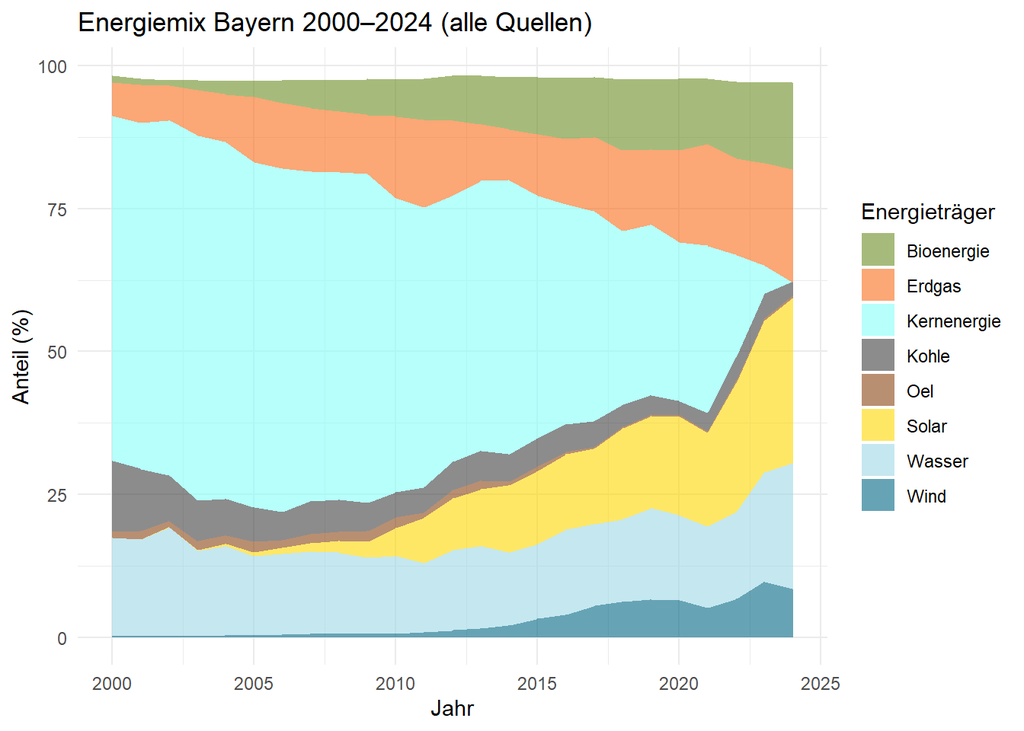

```r
bayern <- bayern |>
  mutate(
    Anteil_Hydro      = Hydro / Insgesamt * 100,
    Anteil_Wind       = Wind / Insgesamt * 100,
    Anteil_Solar      = Solar / Insgesamt * 100,
    Anteil_Biomasse   = Biomasse / Insgesamt * 100
  )

bayern_long_alle <- bayern |>
  select(Jahr, Anteil_Kohlen, Anteil_Oel, Anteil_Erdgas, Anteil_Kernenergie,
         Anteil_Hydro, Anteil_Wind, Anteil_Solar, Anteil_Biomasse) |>
  rename(
    Kohle       = Anteil_Kohlen,
    Oel         = Anteil_Oel,
    Erdgas      = Anteil_Erdgas,
    Kernenergie = Anteil_Kernenergie,
    Wasser      = Anteil_Hydro,
    Wind        = Anteil_Wind,
    Solar       = Anteil_Solar,
    Bioenergie  = Anteil_Biomasse
  ) |>
  pivot_longer(-Jahr, names_to = "Energietraeger", values_to = "Anteil")

ggplot(bayern_long_alle, aes(x = Jahr, y = Anteil, fill = Energietraeger)) +
  geom_area(alpha = 0.6) +
  scale_fill_manual(values = c(
    "Kohle"       = "#404040",
    "Oel"         = "#8B4513",
    "Erdgas"      = "#F96C1B",
    "Kernenergie" = "#85fff9",
    "Wasser"      = "#9ED7E6",
    "Wind"        = "#006884",
    "Solar"       = "#FFD700",
    "Bioenergie"  = "#6B8E23"
  )) +
  labs(title = "Energiemix Bayern 2000–2024 (alle Quellen)",
       x = "Jahr", y = "Anteil (%)", fill = "Energieträger") +
  theme_minimal()
```

Zum Vergleich zeigt die folgende Grafik den gleichen detaillierten Energiemix für Deutschland insgesamt.

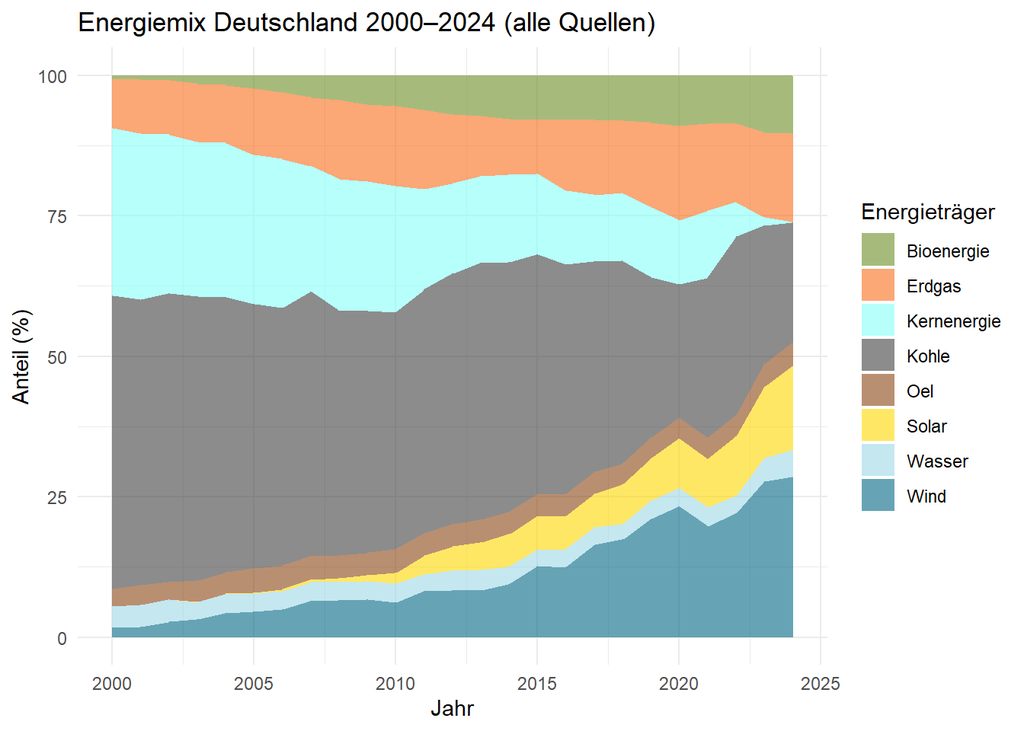

```r
deutschland_long_alle <- deutschland |>
  select(Year, Coal, Oil, Gas, Nuclear, Hydropower, Wind, Solar, Bioenergy) |>
  rename(Jahr = Year,
    Kohle      = Coal,
    Oel         = Oil,
    Erdgas      = Gas,
    Kernenergie = Nuclear,
    Wasser      = Hydropower,
    Wind        = Wind,
    Solar       = Solar,
    Bioenergie  = Bioenergy
  ) |>
  pivot_longer(-Jahr, names_to = "Energietraeger", values_to = "Anteil")

ggplot(deutschland_long_alle, aes(x = Jahr, y = Anteil, fill = Energietraeger)) +
  geom_area(alpha = 0.6) +
  scale_fill_manual(values = c(
    "Kohle"       = "#404040",
    "Oel"         = "#8B4513",
    "Erdgas"      = "#F96C1B",
    "Kernenergie" = "#85fff9",
    "Wasser"      = "#9ED7E6",
    "Wind"        = "#006884",
    "Solar"       = "#FFD700",
    "Bioenergie"  = "#6B8E23"
  )) +
  labs(title = "Energiemix Deutschland 2000–2024 (alle Quellen)",
       x = "Jahr", y = "Anteil (%)", fill = "Energieträger") +
  theme_minimal()
```

### Vereinfachter Energiemix: Fokus auf vier Hauptkategorien

Für die weitere Analyse werden die acht einzelnen Energieträger zu vier Hauptkategorien zusammengefasst: Kohle, Erdgas, Kernenergie und Erneuerbar (als Summe aus Wasser, Wind, Solar und Bioenergie). Diese Vereinfachung konzentriert sich auf die für die Hypothese relevante Unterscheidung und macht den Vergleich zwischen Bayern und Deutschland übersichtlicher.

Die folgende Darstellung zeigt die Entwicklung der vier Hauptenergieträger in Bayern und Deutschland einzeln über den Zeitraum 2000–2024. Jeder Energieträger wird separat betrachtet, um Trends klarer sichtbar zu machen.

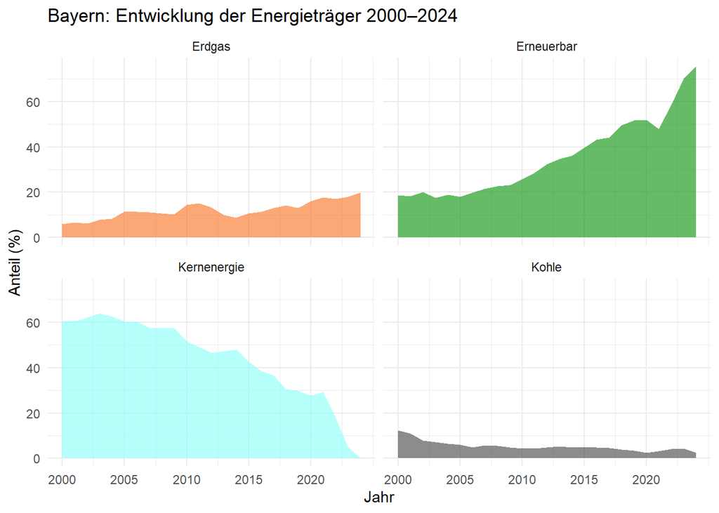

```r
bayern_long <- bayern |>
  select(Jahr, Anteil_Kohlen, Anteil_Erdgas, Anteil_Kernenergie, Anteil_Erneuerbar) |>
  pivot_longer(-Jahr, names_to = "Energietraeger", values_to = "Anteil") |>
  mutate(Energietraeger = recode(Energietraeger,
    "Anteil_Erneuerbar"  = "Erneuerbar",
    "Anteil_Kernenergie" = "Kernenergie",
    "Anteil_Kohlen"      = "Kohle",
    "Anteil_Erdgas"      = "Erdgas"))

ggplot(bayern_long, aes(x = Jahr, y = Anteil, fill = Energietraeger)) +
  geom_area(alpha = 0.6) +
  facet_wrap(~Energietraeger, scales = "fixed") +
  scale_x_continuous(breaks = seq(2000, 2024, by = 5)) +
  scale_fill_manual(values = c(
    "Erneuerbar"  = "#009000",
    "Kernenergie" = "#85fff9",
    "Kohle"       = "#404040",
    "Erdgas"      = "#F96C1B"
  )) +
  labs(title = "Bayern: Entwicklung der Energieträger 2000–2024",
     x = "Jahr", y = "Anteil (%)") +
  theme_minimal() +
  theme(legend.position = "none")
```

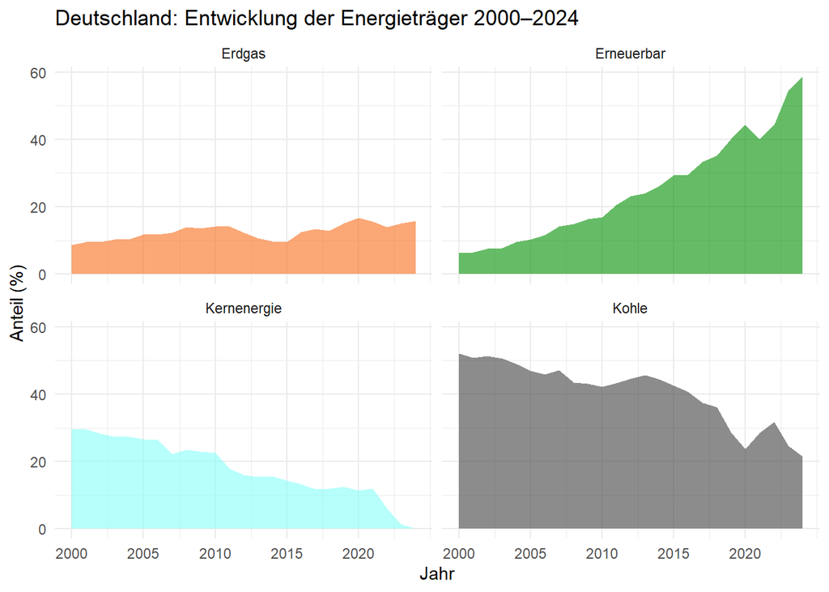

```r
deutschland_long <- deutschland |>
  select(Year, Coal, Gas, Nuclear, Anteil_Erneuerbar) |>
  rename(Jahr = Year,
    Kohle = Coal,
    Erdgas      = Gas,
    Kernenergie = Nuclear,
    Erneuerbar = Anteil_Erneuerbar) |>
  pivot_longer(-Jahr, names_to = "Energietraeger", values_to = "Anteil")


ggplot(deutschland_long, aes(x = Jahr, y = Anteil, fill = Energietraeger)) +
   geom_area(alpha = 0.6) +
  facet_wrap(~Energietraeger, scales = "fixed") +
  scale_x_continuous(breaks = seq(2000, 2024, by = 5)) +
  scale_fill_manual(values = c(
    "Erneuerbar"  = "#009000",
    "Kernenergie" = "#85fff9",
    "Kohle"       = "#404040",
    "Erdgas"      = "#F96C1B"
  )) +
  labs(title = "Deutschland: Entwicklung der Energieträger 2000–2024",
     x = "Jahr", y = "Anteil (%)") +
  theme_minimal() +
  theme(legend.position = "none")
```

Wie die Gesamtübersicht bereits zeigt, haben erneuerbare Energien in beiden Regionen die Kernenergie nahezu vollständig ersetzt. Kohle ist ebenfalls rückläufig — in Bayern war der Anteil bereits 2000 sehr gering und istheute vernachlässigbar. Erdgas hingegen ist leicht gestiegen, was darauf hindeutet, dass es als schnell verfügbare Übergangslösung genutzt wurde, um die wegfallende Kernenergie kurzfristig auszugleichen, bis erneuerbare Energien weiter ausgebaut werden konnten.

### Direkter Vergleich: Energiemix Bayern 2000 vs. 2024

Der folgende Vergleich zeigt für jeden Energieträger den Anteil im Jahr 2000 (hell) und 2024 (dunkel). Besonders auffällig ist der starke Anstieg der erneuerbaren Energien und der vollständige Wegfall der Kernenergie durch den Atomausstieg 2023.

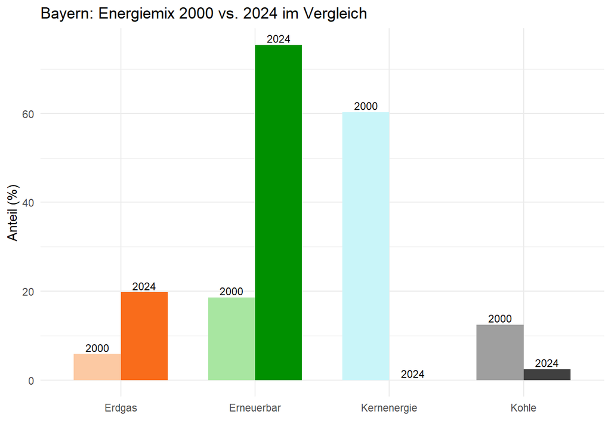

```r
bayern_vergleich <- bayern_long |>
  filter(Jahr %in% c(2000, 2024)) |>
  mutate(Jahr = factor(Jahr), Gruppe = paste(Energietraeger, Jahr))

ggplot(bayern_vergleich, aes(x = Energietraeger, y = Anteil, fill = Gruppe)) +
  geom_col(position = "dodge", width = 0.7) +
  geom_text(aes(label = Jahr), position = position_dodge(width = 0.7),
            vjust = -0.3, size = 3) +
  scale_fill_manual(values = c(
    "Erneuerbar 2000"   = "#A8E6A1", "Erneuerbar 2024"   = "#009000",
    "Kernenergie 2000"  = "#C9F5F9", "Kernenergie 2024"  = "#85fff9",
    "Kohle 2000"        = "#9F9F9F", "Kohle 2024"        = "#404040",
    "Erdgas 2000"       = "#FCC9A3", "Erdgas 2024"       = "#F96C1B"
  )) +
  labs(title = "Bayern: Energiemix 2000 vs. 2024 im Vergleich",
       x = "", y = "Anteil (%)") +
  theme_minimal() +
  theme(legend.position = "none")
```

Zum Vergleich die gleiche Darstellung für Deutschland:

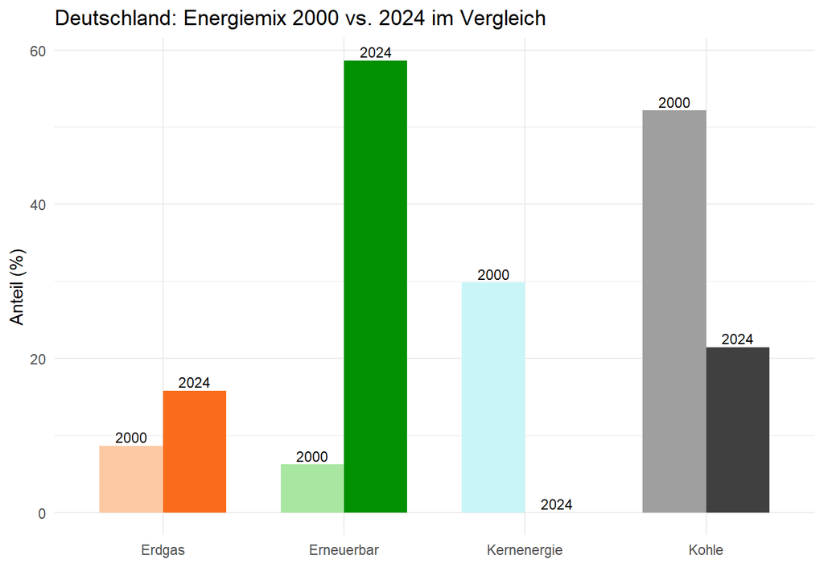

```r
deutschland_vergleich <- deutschland_long |>
  filter(Jahr %in% c(2000, 2024)) |>
  mutate(Jahr = factor(Jahr), Gruppe = paste(Energietraeger, Jahr))

ggplot(deutschland_vergleich, aes(x = Energietraeger, y = Anteil, fill = Gruppe)) +
  geom_col(position = "dodge", width = 0.7) +
  geom_text(aes(label = Jahr), position = position_dodge(width = 0.7),
            vjust = -0.3, size = 3) +
  scale_fill_manual(values = c(
    "Erneuerbar 2000"   = "#A8E6A1", "Erneuerbar 2024"   = "#009000",
    "Kernenergie 2000"  = "#C9F5F9", "Kernenergie 2024"  = "#85fff9",
    "Kohle 2000"        = "#9F9F9F", "Kohle 2024"        = "#404040",
    "Erdgas 2000"       = "#FCC9A3", "Erdgas 2024"       = "#F96C1B"
  )) +
  labs(title = "Deutschland: Energiemix 2000 vs. 2024 im Vergleich",
       x = "", y = "Anteil (%)") +
  theme_minimal() +
  theme(legend.position = "none")
```

Der Vergleich zeigt deutlich: Bayern erreicht 2024 mit ~75% erneuerbarer Energien einen deutlich höheren Anteil als Deutschland mit ~59%. Beide Regionen starteten im Jahr 2000 auf niedrigem Niveau — Bayern bei ~19% und Deutschland bei ~6% — und haben seitdem einen starken Ausbau der Erneuerbaren verzeichnet.

### Energiemix 2024 im direkten Vergleich: Bayern vs. Deutschland

Die folgende Grafik zeigt den aktuellen Energiemix 2024 für Bayern und Deutschland direkt nebeneinander — aufgeteilt nach den vier Hauptenergieträgern.

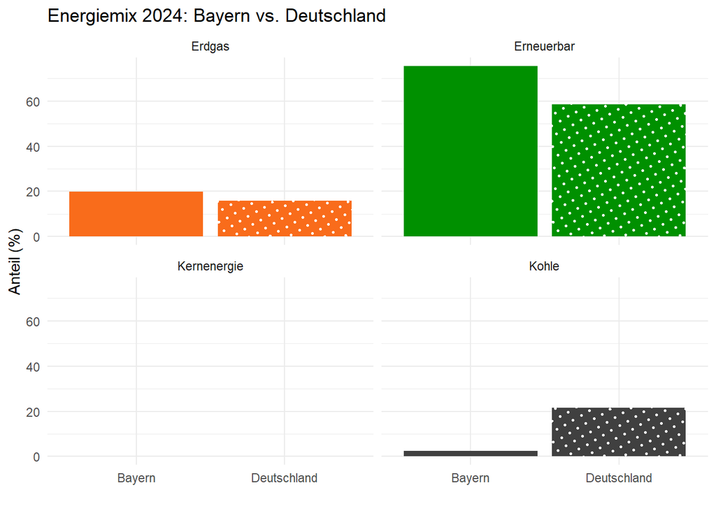

```r
vergleich_2024 <- bind_rows(
  bayern_long |>
    filter(Jahr == 2024) |>
    mutate(Region = "Bayern"),

  deutschland_long |>
    filter(Jahr == 2024) |>
    mutate(Region = "Deutschland"))


ggplot(vergleich_2024, aes(x = Region, y = Anteil, fill = Energietraeger, pattern = Region)) +
 geom_col_pattern(
   color = NA,   # kein Balken-Rahmen
   pattern_colour = NA,  # kein Muster-Rahmen
    pattern_density = 0.3,
    pattern_spacing = 0.05,
    pattern_fill    = "white"
  ) +
  scale_fill_manual(values = c(
    "Erneuerbar"  = "#009000",
    "Kernenergie" = "#85fff9",
    "Kohle"       = "#404040",
    "Erdgas"      = "#F96C1B"
  )) +
  scale_pattern_manual(values = c(
    "Bayern"       = "none",     # volle Farbe
    "Deutschland"  = "circle"    # dot
  )) +
  facet_wrap(~Energietraeger, scales = "fixed") +
  labs(title = "Energiemix 2024: Bayern vs. Deutschland",
       x = "", y = "Anteil (%)") +
  theme_minimal() +
theme(legend.position = "none")
```

Um einen besseren Überblick zu erhalten, zeigen die folgenden Grafiken die Entwicklung der Anteile der wichtigsten Energieträger in Bayern und Deutschland von 2000 bis 2024.

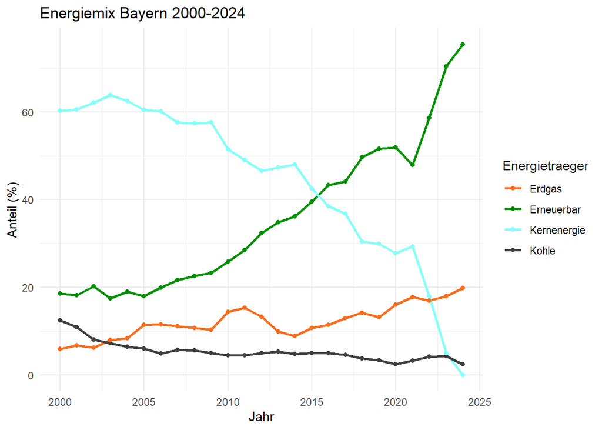

```r
# Zeitreihe – mehrere Variablen gemeinsam (BY)
ggplot(bayern_long, aes(x = Jahr, y = Anteil, color = Energietraeger)) +
  geom_line(linewidth = 1) +
  geom_point(size = 1.5) +
  scale_color_manual(values = c(
    "Erneuerbar"  = "#009000",
    "Kernenergie" = "#85fff9",
    "Kohle"       = "#404040",
    "Erdgas"      = "#F96C1B"
  )) +
  labs(title = "Energiemix Bayern 2000-2024",
       x = "Jahr", y = "Anteil (%)") +
  theme_minimal()
```

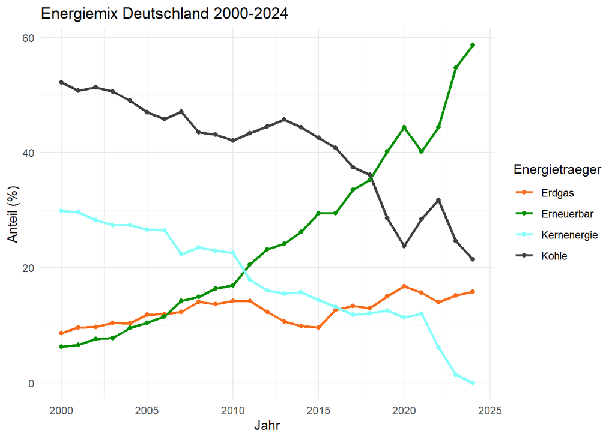

```r
# Zeitreihe – mehrere Variablen gemeinsam (DE)
ggplot(deutschland_long, aes(x = Jahr, y = Anteil, color = Energietraeger)) +
  geom_line(linewidth = 1) +
  geom_point(size = 1.5) +
  scale_color_manual(values = c(
    "Erneuerbar"  = "#009000",
    "Kernenergie" = "#85fff9",
    "Kohle"       = "#404040",
    "Erdgas"      = "#F96C1B"
    )) +
  labs(title = "Energiemix Deutschland 2000-2024",
       x = "Jahr", y = "Anteil (%)") +
  theme_minimal()
```

Die Grafiken zeigen deutlich, dass sowohl in Bayern als auch in Deutschland der Anteil der Kernenergie im Zeitraum 2000–2024 auf 0% gesunken ist – in Deutschland von rund 30% und in Bayern sogar von rund 60%. Dieser Rückgang ist auf den deutschen Atomausstieg zurückzuführen, der 2023 abgeschlossen wurde. Gleichzeitig ist in beiden Regionen der Anteil erneuerbarer Energien stark gestiegen, was darauf hindeutet, dass die Kernenergie weitgehend durch erneuerbare Quellen ersetzt wurde. Auch der Anteil der Kohle ging in beiden Regionen zurück. Interessant ist dabei, dass der Anteil des Erdgases parallel zum Anstieg der erneuerbaren Energien ebenfalls zugenommen hat – Erdgas diente in dieser Übergangsphase vermutlich als Brückentechnologie, um Schwankungen bei der erneuerbaren Stromerzeugung auszugleichen.

# 4. Ausreißeranalyse

### Box-Plot

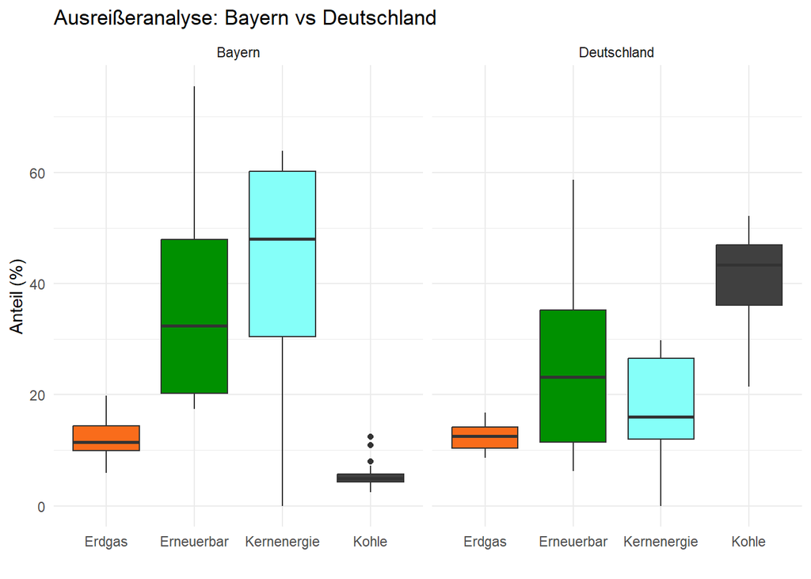

```r
# Beide Datensätze zusammenfügen
bayern_box <- bayern_long |>
  mutate(Region = "Bayern")

deutschland_box <- deutschland_long |>
  mutate(Region = "Deutschland")

beide_box <- bind_rows(bayern_box, deutschland_box)

# Boxplot
ggplot(beide_box, aes(x = Energietraeger, y = Anteil, fill = Energietraeger)) +
  geom_boxplot() +
  facet_wrap(~Region) +
  scale_fill_manual(values = c(
    "Erneuerbar"  = "#009000",
    "Kernenergie" = "#85fff9",
    "Kohle"       = "#404040",
    "Erdgas"      = "#F96C1B"
    )) +
  labs(title = "Ausreißeranalyse: Bayern vs Deutschland",
       x = "", y = "Anteil (%)") +
  theme_minimal() +
  theme(legend.position = "none")
```

Der Boxplot bestätigt den bereits beobachteten Trend: Die Kernenergie weist in Bayern die größte Streuung auf – von rund 60% bis 0% – was den vollständigen Ersatz durch erneuerbare Energien widerspiegelt. In Bayern lag der Anteil erneuerbarer Energien in 50% der Jahre zwischen ca. 20% und 48%, in Deutschland zwischen ca. 12% und 35%. Insgesamt sind keine problematischen Ausreißer erkennbar.

**Warum sind Ausreißer problematisch?** Extreme Beobachtungen können statistische Kennzahlen wie Mittelwert und Standardabweichung stark verzerren. Besonders bei linearen Regressionen können einzelne Ausreißer die Steigung der Geraden beeinflussen und damit zu falschen Schlussfolgerungen führen.

**Handling** Ein gängiger Ansatz ist die IQR-Regel: Werte die mehr als 1.5 × IQR unter dem 1. Quartil oder über dem 3. Quartil liegen, gelten als Ausreißer. Diese können dann entweder entfernt oder durch den Grenzwert ersetzt werden. Wie gesagt in meinem Datensatz sind jedoch keine problematischen Ausreißer erkennbar — die Verteilungen bei der Kernenergie in Bayern spiegeln den realen Atomausstieg wider und sind daher inhaltlich erklärbar, nicht statistisch auffällig.

# 5. Anonymisierung

### Beispiel

Die verwendeten Datensätze enthalten keine personenbezogenen Daten, da es sich um aggregierte Energiestatistiken auf Länder- bzw. Regionalebene handelt. Anonymisierung ist daher nicht erforderlich. Als Beispiel könnte man sich einen Datensatz vorstellen, bei dem einzelne Energieunternehmen ihre vorhergesagte Stromerzeugung je Energieträger melden. Dort wären Variablen wie Unternehmensname oder Standort kritisch, da sie Rückschlüsse auf die Geschäftsstrategie und Wettbewerbsposition einzelner Unternehmen erlauben könnten. Ein möglicher Lösungsansatz wäre die Aggregation der Daten auf regionaler Ebene, sodass keine Rückschlüsse auf einzelne Unternehmen möglich sind.

# 6. Info-Grafik

### Überprüfung der Hypothese: Ist Bayern wirklich Vorreiter der Energiewende?

Die folgende Info-Grafik überprüft die Hypothese, ob der Anteil erneuerbarer Energien in Bayern höher ist als der deutsche Durchschnitt und schneller wächst. Zusätzlich wird Bayern mit dem EU- und Weltdurchschnitt verglichen, um einzuordnen, ob Bayern nicht nur im nationalen, sondern auch im internationalen Kontext eine Vorreiterrolle einnimmt.

```r
# Alle Regionen zusammenfügen
alle_regionen <- bayern |>
  select(Jahr, Anteil_Erneuerbar) |>
  mutate(Region = "Bayern") |>
  bind_rows(
    deutschland |>
      select(Year, Anteil_Erneuerbar) |>
      rename(Jahr = Year) |>
      mutate(Region = "Deutschland"),
    eu |>
      select(Year, Anteil_Erneuerbar) |>
      rename(Jahr = Year) |>
      mutate(Region = "EU"),
    welt |>
      select(Year, Anteil_Erneuerbar) |>
      rename(Jahr = Year) |>
      mutate(Region = "Welt")
  )
```

### Zeitreihe alle 4 Regionen

- **x-Achse:** `Jahr` -> metrisch
- **y-Achse:** `Anteil_Erneuerbar` -> metrisch
- **Farbe:** `Region` -> kategorial

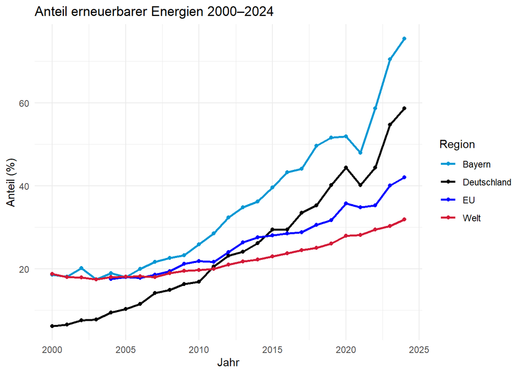

```r
ggplot(alle_regionen, aes(x = Jahr, y = Anteil_Erneuerbar, color = Region)) +
  geom_line(linewidth = 1) +
  geom_point(size = 1.5) +
  scale_color_manual(values = c(
    "Bayern"      = "#0098D4",
    "Deutschland" = "#000000",
    "EU"          = "#0000FF",
    "Welt"        = "#D31A38"
  )) +
  labs(title = "Anteil erneuerbarer Energien 2000–2024",
       x = "Jahr", y = "Anteil (%)") +
  theme_minimal()
```

### Anteil erneuerbarer Energien im regionalen Vergleich: 2004 vs. 2024

Die folgende Grafik vergleicht den Anteil erneuerbarer Energien in Bayern, Deutschland, der EU und der Welt für die Jahre 2004 und 2024. Der Startzeitpunkt 2004 wurde gewählt, da für die EU in den Jahren 2000–2003 keine Winddaten vorlagen (NA). Da die Berechnung des Gesamtanteils erneuerbarer Energien die Windkomponente enthält, ergab die Summe ebenfalls NA — ein sinnvoller Vergleichswert für die EU wäre für diesen Zeitraum nicht möglich gewesen.

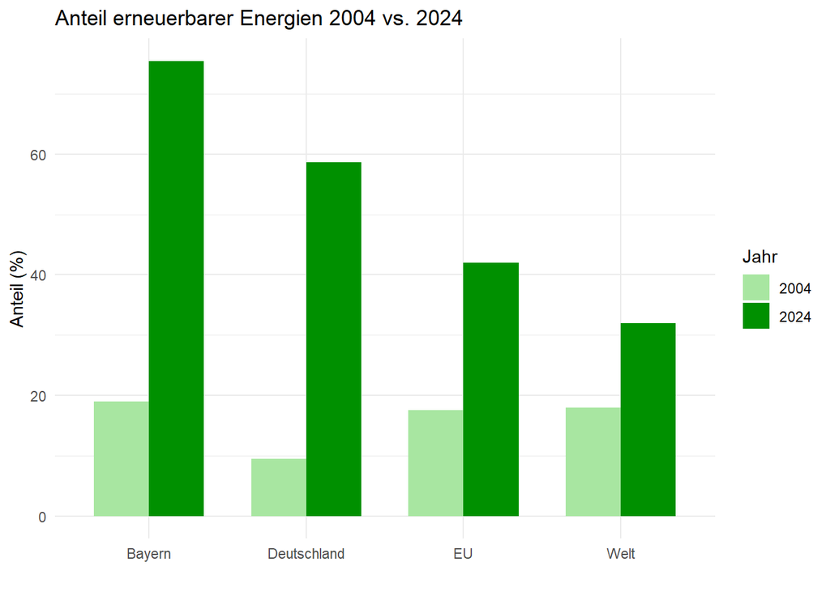

```r
vergleich_ee <- bind_rows(
  bayern |>
    filter(Jahr %in% c(2004, 2024)) |>
    select(Jahr, Anteil_Erneuerbar) |>
    mutate(Region = "Bayern"),

  deutschland |>
    filter(Year %in% c(2004, 2024)) |>
    select(Jahr = Year, Anteil_Erneuerbar) |>
    mutate(Region = "Deutschland"),

  eu |>
    filter(Year %in% c(2004, 2024)) |>
    select(Jahr = Year, Anteil_Erneuerbar) |>
    mutate(Region = "EU"),

  welt |>
    filter(Year %in% c(2004, 2024)) |>
    select(Jahr = Year, Anteil_Erneuerbar) |>
    mutate(Region = "Welt")
) |>
  mutate(
    Region = factor(Region, levels = c("Bayern", "Deutschland", "EU", "Welt")),
    Jahr = factor(Jahr)
  )

ggplot(vergleich_ee, aes(x = Region, y = Anteil_Erneuerbar, fill = Jahr)) +
  geom_col(position = "dodge", width = 0.7) +
  scale_fill_manual(values = c("2004" = "#A8E6A1", "2024" = "#009000")) +
  labs(title = "Anteil erneuerbarer Energien 2004 vs. 2024",
       x = "", y = "Anteil (%)", fill = "Jahr") +
  theme_minimal()
```

Die Grafik bestätigt die Hypothese: Bayern nimmt nicht nur gegenüber Deutschland, sondern auch im europäischen und globalen Kontext eine Vorreiterrolle ein. Während alle Regionen seit 2004 deutlich gewachsen sind, liegt Bayern 2024 als einzige Region über 70%.

### Wachstumsgeschwindigkeit

Um zu überprüfen, ob Bayern nicht nur einen höheren Anteil erneuerbarer Energien aufweist, sondern auch schneller wächst als der deutsche Durchschnitt, wird im Folgenden eine lineare Regression durchgeführt. Die Steigung der Regressionsgeraden gibt dabei an, um wie viele Prozentpunkte der Anteil erneuerbarer Energien pro Jahr durchschnittlich gestiegen ist. Eine höhere Steigung bedeutet ein schnelleres Wachstum.

- **x-Achse:** `Jahr` -> metrisch
- **y-Achse:** `Anteil_Erneuerbar` -> metrisch
- **Farbe:** `Region` -> kategorial
- **Steigung:** Wachstumsrate pro Jahr -> metrisch

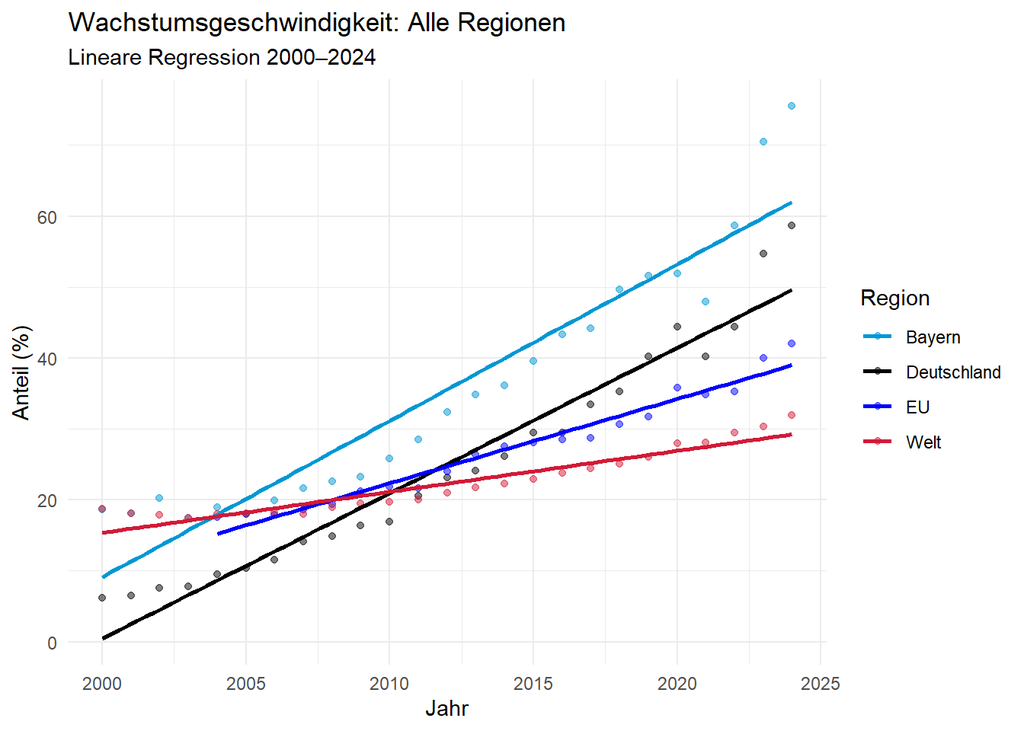

```r
ggplot(alle_regionen, aes(x = Jahr, y = Anteil_Erneuerbar, color = Region)) +
  geom_point(alpha = 0.5) +
  geom_smooth(method = "lm", se = FALSE) +
  scale_color_manual(name = "Region",
                     values = c(
                       "Bayern"      = "#0098D4",
                       "Deutschland" = "#000000",
                       "EU"          = "#0000FF",
                       "Welt"        = "#D31A38"
                     )) +
  labs(title = "Wachstumsgeschwindigkeit: Alle Regionen",
       subtitle = "Lineare Regression 2000–2024",
       x = "Jahr", y = "Anteil (%)") +
  theme_minimal()
```

- **Bayern und Deutschland** wachsen ähnlich schnell (parallele Linien)
- Bayern liegt jedoch **konstant höher** als Deutschland
- Bayern hat **mehr** erneuerbare Energien, wächst aber nicht unbedingt **schneller**